# Stat184 Final Project-Claire Jablonski

My final projects involves investigating a set of Thanksgiving 2015 data. Participants were asked 23 questions about their Thanksgiving celebrations & traditions, Thanksgiving festivities including Black Friday plans, and describing their background. From exploring and manipulating the data, I was able to learn more about all respondents and draw conconclusions about groups of people. The purpose of my project was to investigate relationships between categorical data. It is important to note that for some of investigations I truncated the range to only include the lower bound and not the upper bound.

```r
# Reading Thanksgiving Data with read.csv()
myURL <- "/Users/clairejablonski/Downloads/data-master/thanksgiving-2015/thanksgiving-2015-poll-data.csv"
ThanksgivingData <- read.csv(myURL)
```

I began by renaming variables and removing variables that were not needed. I created a new data table called TidyThanksgiving which presented the data with nicer variable names and cleaner set up.

```r
TidyThanksgivingData <-
  ThanksgivingData %>%
  rename(Respondent = RespondentID, CelebrateThanksgiving = Do.you.celebrate.Thanksgiving., MainDish = What.is.typically.the.main.dish.at.your.Thanksgiving.dinner., MainDishCooked = How.is.the.main.dish.typically.cooked., TypeofStuffing = What.kind.of.stuffing.dressing.do.you.typically.have., TypeofCranberrySauce = What.type.of.cranberry.saucedo.you.typically.have., Gravy = Do.you.typically.have.gravy., PrayatMeal = Do.you.typically.pray.before.or.after.the.Thanksgiving.meal., TravelDistance = How.far.will.you.travel.for.Thanksgiving., WatchMacysParade = Will.you.watch.any.of.the.following.programs.on.Thanksgiving..Please.select.all.that.apply....Macy.s.Parade, KidsTableAgeCutoff = What.s.the.age.cutoff.at.your..kids..table..at.Thanksgiving., Sex = What.is.your.gender., HouseholdCombinedSalary = How.much.total.combined.money.did.all.members.of.your.HOUSEHOLD.earn.last.year., LivingArea = How.would.you.describe.where.you.live. ) %>%
  select(-How.is.the.main.dish.typically.cooked....Other..please.specify., -What.kind.of.stuffing.dressing.do.you.typically.have....Other..please.specify., -What.type.of.cranberry.saucedo.you.typically.have....Other..please.specify., -Which.of.these.side.dishes.aretypically.served.at.your.Thanksgiving.dinner..Please.select.all.that.apply....Other..please.specify..1, -Which.of.these.side.dishes.aretypically.served.at.your.Thanksgiving.dinner..Please.select.all.that.apply....Other..please.specify., -Which.type.of.pie.is.typically.served.at.your.Thanksgiving.dinner..Please.select.all.that.apply....Other..please.specify., -Which.type.of.pie.is.typically.served.at.your.Thanksgiving.dinner..Please.select.all.that.apply....Other..please.specify..1, -Which.of.these.desserts.do.you.typically.have.at.Thanksgiving.dinner..Please.select.all.that.apply......Other..please.specify., -Which.of.these.desserts.do.you.typically.have.at.Thanksgiving.dinner..Please.select.all.that.apply......Other..please.specify..1)
```

```r
# head() was used to show a snapshot of the data table
head(TidyThanksgivingData)
```

|  | Respondent | CelebrateThanksgiving | MainDish | What.is.typically.the.main.dish.at.your.Thanksgiving.dinner....Other..please.specify. | MainDishCooked | TypeofStuffing | TypeofCranberrySauce | Gravy | Which.of.these.side.dishes.aretypically.served.at.your.Thanksgiving.dinner..Please.select.all.that.apply....Brussel.sprouts | Which.of.these.side.dishes.aretypically.served.at.your.Thanksgiving.dinner..Please.select.all.that.apply....Carrots | Which.of.these.side.dishes.aretypically.served.at.your.Thanksgiving.dinner..Please.select.all.that.apply....Cauliflower | Which.of.these.side.dishes.aretypically.served.at.your.Thanksgiving.dinner..Please.select.all.that.apply....Corn | Which.of.these.side.dishes.aretypically.served.at.your.Thanksgiving.dinner..Please.select.all.that.apply....Cornbread | Which.of.these.side.dishes.aretypically.served.at.your.Thanksgiving.dinner..Please.select.all.that.apply....Fruit.salad | Which.of.these.side.dishes.aretypically.served.at.your.Thanksgiving.dinner..Please.select.all.that.apply....Green.beans.green.bean.casserole | Which.of.these.side.dishes.aretypically.served.at.your.Thanksgiving.dinner..Please.select.all.that.apply....Macaroni.and.cheese | Which.of.these.side.dishes.aretypically.served.at.your.Thanksgiving.dinner..Please.select.all.that.apply....Mashed.potatoes | Which.of.these.side.dishes.aretypically.served.at.your.Thanksgiving.dinner..Please.select.all.that.apply....Rolls.biscuits | Which.of.these.side.dishes.aretypically.served.at.your.Thanksgiving.dinner..Please.select.all.that.apply....Squash | Which.of.these.side.dishes.aretypically.served.at.your.Thanksgiving.dinner..Please.select.all.that.apply....Vegetable.salad | Which.of.these.side.dishes.aretypically.served.at.your.Thanksgiving.dinner..Please.select.all.that.apply....Yams.sweet.potato.casserole | Which.type.of.pie.is.typically.served.at.your.Thanksgiving.dinner..Please.select.all.that.apply....Apple | Which.type.of.pie.is.typically.served.at.your.Thanksgiving.dinner..Please.select.all.that.apply....Buttermilk | Which.type.of.pie.is.typically.served.at.your.Thanksgiving.dinner..Please.select.all.that.apply....Cherry | Which.type.of.pie.is.typically.served.at.your.Thanksgiving.dinner..Please.select.all.that.apply....Chocolate | Which.type.of.pie.is.typically.served.at.your.Thanksgiving.dinner..Please.select.all.that.apply....Coconut.cream | Which.type.of.pie.is.typically.served.at.your.Thanksgiving.dinner..Please.select.all.that.apply....Key.lime | Which.type.of.pie.is.typically.served.at.your.Thanksgiving.dinner..Please.select.all.that.apply....Peach | Which.type.of.pie.is.typically.served.at.your.Thanksgiving.dinner..Please.select.all.that.apply....Pecan | … |
| --- | --- | --- | --- | --- | --- | --- | --- | --- | --- | --- | --- | --- | --- | --- | --- | --- | --- | --- | --- | --- | --- | --- | --- | --- | --- | --- | --- | --- | --- | --- |
| 1 | 4337954960 | Yes | Turkey |  | Baked | Bread-based | None | Yes |  | Carrots |  |  |  |  | Green beans/green bean casserole | Macaroni and cheese | Mashed potatoes |  |  |  | Yams/sweet potato casserole | Apple |  |  |  |  |  |  |  | … |
| 2 | 4337951949 | Yes | Turkey |  | Baked | Bread-based | Other (please specify) | Yes |  |  |  | Corn |  |  | Green beans/green bean casserole | Macaroni and cheese | Mashed potatoes | Rolls/biscuits |  | Vegetable salad | Yams/sweet potato casserole | Apple |  |  | Chocolate |  |  |  |  | … |
| 3 | 4337935621 | Yes | Turkey |  | Roasted | Rice-based | Homemade | Yes | Brussel sprouts | Carrots | Cauliflower | Corn | Cornbread |  |  |  | Mashed potatoes | Rolls/biscuits |  | Vegetable salad |  | Apple |  | Cherry |  |  |  | Peach | Pecan | … |
| 4 | 4337933040 | Yes | Turkey |  | Baked | Bread-based | Homemade | Yes | Brussel sprouts |  |  |  | Cornbread |  |  |  | Mashed potatoes | Rolls/biscuits |  | Vegetable salad | Yams/sweet potato casserole |  |  |  |  |  |  |  | Pecan | … |
| 5 | 4337931983 | Yes | Tofurkey |  | Baked | Bread-based | Canned | Yes | Brussel sprouts |  |  |  | Cornbread |  |  |  | Mashed potatoes | Rolls/biscuits | Squash | Vegetable salad | Yams/sweet potato casserole | Apple |  |  |  |  |  |  |  | … |
| 6 | 4337929779 | Yes | Turkey |  | Roasted | Rice-based | Homemade | Yes | Brussel sprouts | Carrots | Cauliflower | Corn | Cornbread | Fruit salad | Green beans/green bean casserole | Macaroni and cheese | Mashed potatoes | Rolls/biscuits | Squash | Vegetable salad | Yams/sweet potato casserole |  |  |  |  |  |  |  |  | … |

# Who celebrates Thanksgiving the most?

After creating a tidy data table, I wanted to know exactly how many of the responents celebrate Thanksgiving. To do this, I filtered out those that do celebrate Thanksgiving and found that 980 out of the 1058 people celebrate Thanksgiving.

```r
TidyThanksgivingData %>%
  filter(CelebrateThanksgiving == "Yes") %>%
  summarise(total = n())
```

| total |
| --- |
| 980 |

Next, I was interested in how many females and males responded to this survey.Grouping by sex shows that there were 544 women who completed the survey and 481 males that completed the survey. 33 people choose not to record their sex and have been removed from the information provided below.

```r
TidyThanksgivingData %>%
  group_by(Sex) %>%
  filter(Sex != "") %>% # Removes anyone who did not list their sex
  summarise(total = n())
```

| Sex | total |
| --- | --- |
| Female | 544 |
| Male | 481 |

I then created a data table called “Celebrate” that showed the split betwen sex and age group for those that do celebrate Thanksgiving. What I was interested in learning was if there was a big difference between sexes for each age group.By creating a dot plot it was easy to see the difference between the two sexes. There were more females than males for every age category.It is not suprising that there are more females that celebrate Thanksgiving in each category because more females completed the survey than males.

It was also interesting to see that females 60+ celebrate Thanksgiving the most with a total of 144 people celebrating. Males aged 45-59 celebrate Thanksgiving the most with 127 people celebrating. The biggest difference between the number of females and males that celebrate Thanksgiving is for 60+ people. The smallest difference between the number of females and males that celebrate Thanksgiving is for the people between 45-59 age range.

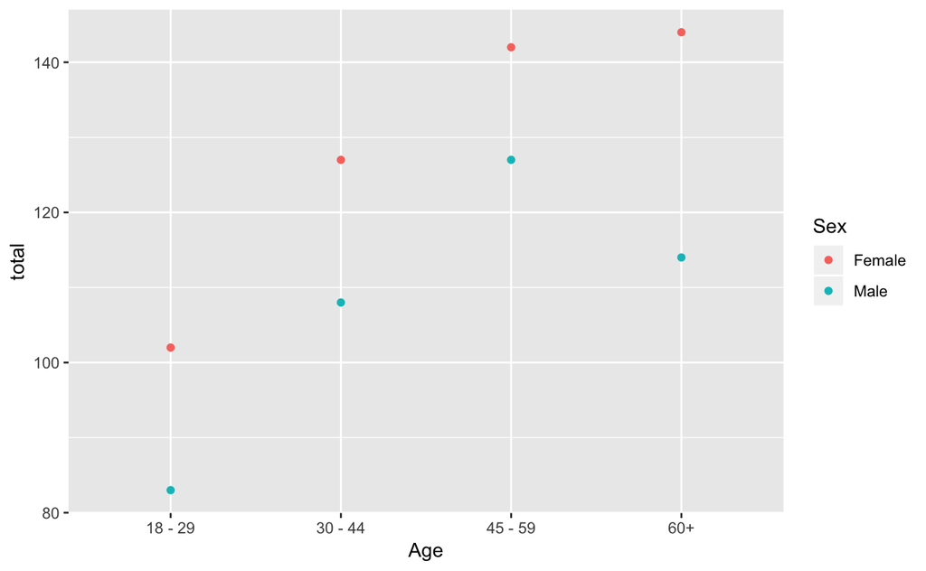

```r
Celebrate <-
  TidyThanksgivingData %>%
  filter(CelebrateThanksgiving =="Yes") %>%
  filter(Sex != "")%>%
  group_by(Sex,Age) %>%
  summarise(total = n()) # summarise() tells the total number of people that complete each aspect of a category

Celebrate %>%
  ggplot(aes(x= Age, y=total)) +
  geom_point(aes(color = Sex))
```

# What is the relationship between Household Combined Salaries and whether you work in Retail?

Next, I wanted to investigate the relationship between household combined salary ranges with if the person worked in retail or not. I created a new data table called “RetailSalary” to compare people who work in retail with those who don’t work in retail based on what their household combined salaries were. The graph below shows that more people did not work in retail than did work in retail. The graph also shows that people who did not work in retail had higher household combined salaries.

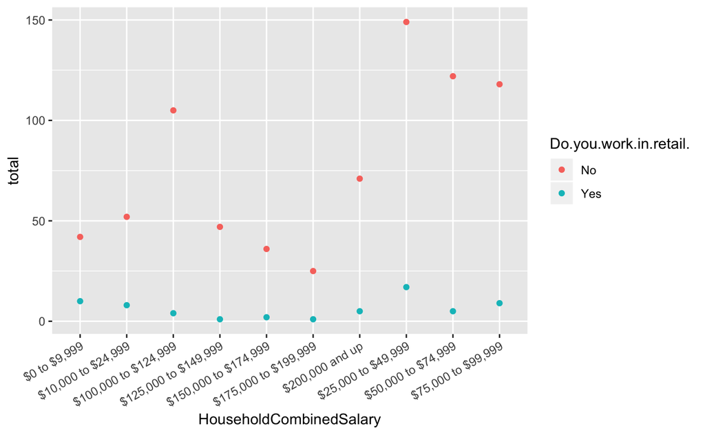

```r
# Created new data table called RetailSalary where I grouped by if they worked in retail or not and their household combined salary
RetailSalary <-
  TidyThanksgivingData %>%
  group_by(Do.you.work.in.retail.,HouseholdCombinedSalary ) %>%
  filter(Do.you.work.in.retail. != "") %>%                                                       # Filter out those who did not respond to the question Do you work in retail
  filter(HouseholdCombinedSalary != "", HouseholdCombinedSalary != "Prefer not to answer") %>%   # Filter out those that did not share their combined household salary or perfered not to answer
  summarise(total = n()) %>%
  arrange(desc(total))
RetailSalary %>%
  ggplot(aes(x = HouseholdCombinedSalary, y = total)) +
  geom_point(aes( color = Do.you.work.in.retail.)) +
  theme(axis.text.x = element_text(angle = 30, hjust =1))
```

```r
# Used theme() to have the x variable written at a slant so it can be visible on the graph
```

# What is the most popular Main Dish cooked in all US Regions? How is it cooked?

From looking at the original TidyThanksgivingData, I was interested in comparing different regions people live in and their main dish for Thanksgiving and how it is cooked. I expected that turkey would be the main dish for all regions and that baking the turkey would be the most popular option.I created a data table “USRegionMainDish” that explored these variables.From the table we can see that the most amount of people live in the South Atlantic and bake turkey.From looking at the chart it is difficult to see if baking or roasted is most popular cooking method and if turkey is the most popular food choice. To try and clear this up a plot was created that created a facet for each US Region exploring the differences in the food cooked and the cooking methods used.

```r
USRegionMainDish <-
  TidyThanksgivingData %>%
  group_by(US.Region, MainDish, MainDishCooked) %>%
  filter(US.Region != "") %>%
  filter(MainDish !="Other (please specify)") %>%
  filter(MainDish != "") %>%
  filter(MainDish != "I don't know") %>%
  filter(MainDishCooked !="Other (please specify)") %>%
  filter(MainDishCooked != "I don't know") %>%
  summarise(total = n())
USRegionMainDish %>%
  arrange( desc(total)) # Arranging the data in descending order according to total amount
```

| US.Region | MainDish | MainDishCooked | total |
| --- | --- | --- | --- |
| South Atlantic | Turkey | Baked | 96 |
| East North Central | Turkey | Baked | 73 |
| Middle Atlantic | Turkey | Roasted | 68 |
| South Atlantic | Turkey | Roasted | 63 |
| Pacific | Turkey | Baked | 59 |
| East North Central | Turkey | Roasted | 54 |
| Middle Atlantic | Turkey | Baked | 54 |
| West South Central | Turkey | Baked | 42 |
| Pacific | Turkey | Roasted | 40 |
| West North Central | Turkey | Baked | 36 |

[output cut: 48 more lines]

From this graph it is now obvious that in each region that turkey is more served than anyother dish. What we cannot really tell from this graph is the way that most people cook their main dish it really varies from region to region and there is no distinct pattern seen from it. Other factors may have an influenece like age, sex, or income. Let us explore what age has to do with the style in how people cook their turkey.

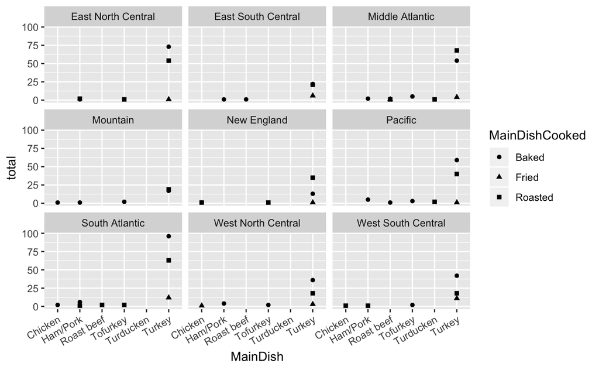

```r
USRegionMainDish %>%
  ggplot(aes(x = MainDish , y = total )) +
  geom_point( aes(shape = MainDishCooked)) +
  facet_wrap( ~ US.Region) +
  theme(axis.text.x = element_text(angle = 30, hjust =1))
```

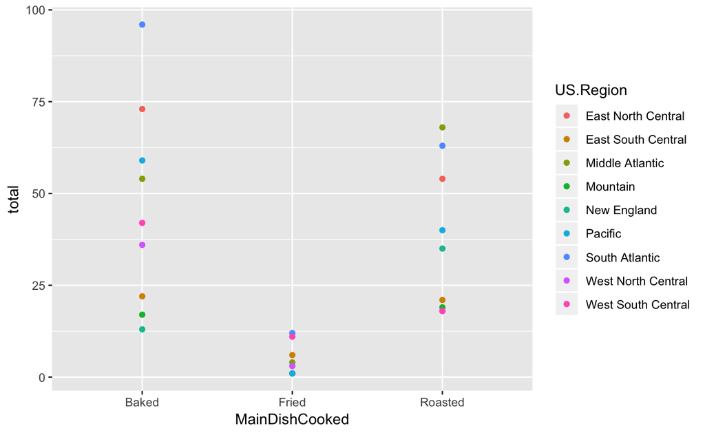

```r
USRegionMainDish %>%
  filter(MainDish == "Turkey" ) %>%
  ggplot(aes(x = MainDishCooked , y = total )) +
  geom_point(aes(color = US.Region))
```

```r
NA
```

```r
MainDishCookedAge <-
  TidyThanksgivingData %>%
  group_by(Age, MainDishCooked) %>%
  summarise(total = n()) %>%
  filter(MainDishCooked !="", MainDishCooked != "Other (please specify)", MainDishCooked != "I don't know", Age != "") %>%
  arrange( desc(total) )
head(MainDishCookedAge)
```

| Age | MainDishCooked | total |
| --- | --- | --- |
| 30 - 44 | Baked | 131 |
| 60+ | Roasted | 130 |
| 45 - 59 | Baked | 128 |
| 45 - 59 | Roasted | 109 |
| 18 - 29 | Baked | 108 |
| 60+ | Baked | 104 |

# What is the mean Age and Salary of Surveyors?

From looking at the data, I was really interested in seeing the average age and salary people earned in the TidyThanksgivingData. To do this I created a new HouseholdSalary data table where I truncated the age and and household combined salary. To truncate the household combined salary, I created a new variable called salary that only contained the first value of the range of values. It was interesting exploring these variables and seeing that the average truncated salary was $74,077.62. The average truncated age that responded to this survey was 42 years old. It is important to see that the average truncated age was 42 showing that mostly older people responded to this survey.

```r
HouseholdSalary <-
  TidyThanksgivingData %>%
  mutate( HouseholdCombinedSalary=gsub("[$,%]|to|and up","",HouseholdCombinedSalary)) %>%
  # Removed $ and the words that indicated range for HouseholdCombinedSalary
  mutate( Age=gsub("[-, 29, 44, +]","", Age)) %>%
  # Removed the range values for Age variable
  mutate(Age = as.numeric(Age)) %>%
  # Made sure Age was a numeric variable
  mutate(Salary=if_else(condition = (HouseholdCombinedSalary == "Prefer not answer"), true = as.character(NA), false = str_extract(string = HouseholdCombinedSalary, pattern = "^[[:digit:]]+" ))) %>%
  # Create a new variable Salary that only contains the first value of the range of values for the HouseholdCombinedSalary
  mutate(Salary = as.numeric(Salary))
```

```r
HouseholdSalary %>%
summarise(mean(Salary, na.rm = TRUE))
```

| mean(Salary, na.rm = TRUE) |
| --- |
| 74077.62 |

```r
HouseholdSalary %>%
  summarise(mean(Age, na.rm = TRUE))
```

| mean(Age, na.rm = TRUE) |
| --- |
| 42.17366 |

With this truncated data, I was also interested in creating a tree graph to display Age and Salary. I think it is interesting and it makes sense that as you get older your salary will increase. One thing to take note of is that no one took the survey that was under 18 years old so it does not make sense that when you are under 18 your early salary will be $42,660.82. I also think it is interesting to see that people between the ages of 18 and 30 earn a yearly salary of $64,466.67 which is around $10,000 less than the mean salary for all people surveyed. Tree graphs make it easy to make connections between data!

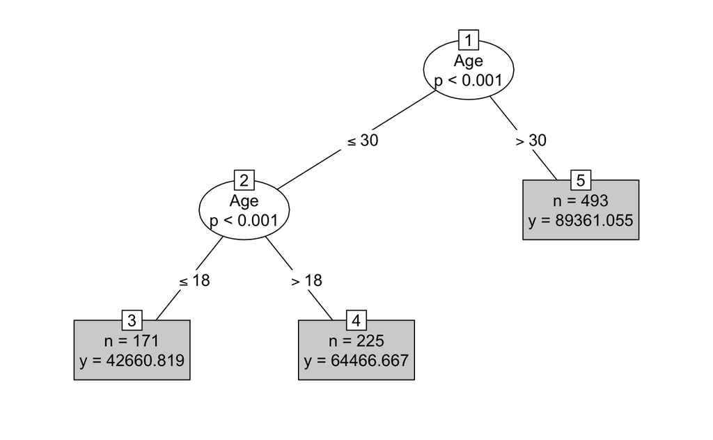

```r
TidyHouseholdSalary <-
  HouseholdSalary %>%
  filter(Age !="NA") %>%
  filter(Salary !="NA") %>%
  filter(Sex != "")
MyModel <-
  party::ctree(Salary ~ Age + Sex, data = TidyHouseholdSalary)
plot(MyModel, type = "simple")
```

# Are Sex and Praying Before a Meal correlated?

Working with all categorical variables can be tough when trying to analyze the data. But looking at my data, I was interested in seeing if there was a correlation between praying before Thanksgiving dinner and sex. First, I created a new data table called “PrayBeforeMeal”. This data table summarized the total amount of males and females who do and do not pray before Thanksgiving dinner. It was interesting to see that there were very similar totals for males and females in who prayed and who did not pray before Thanksgiving.

```r
PrayBeforeMeal <-
TidyThanksgivingData %>%
  group_by(PrayatMeal, Sex ) %>%
  filter(PrayatMeal != "") %>%
  filter(Sex != "") %>%
  mutate( Age=gsub("[-, 29, 44, +]","", Age)) %>%
  mutate(Age = as.numeric(Age)) %>%
  summarise(total = n())
PrayBeforeMeal %>%
  arrange( desc(total))
```

| PrayatMeal | Sex | total |
| --- | --- | --- |
| Yes | Female | 341 |
| Yes | Male | 280 |
| No | Female | 174 |
| No | Male | 152 |

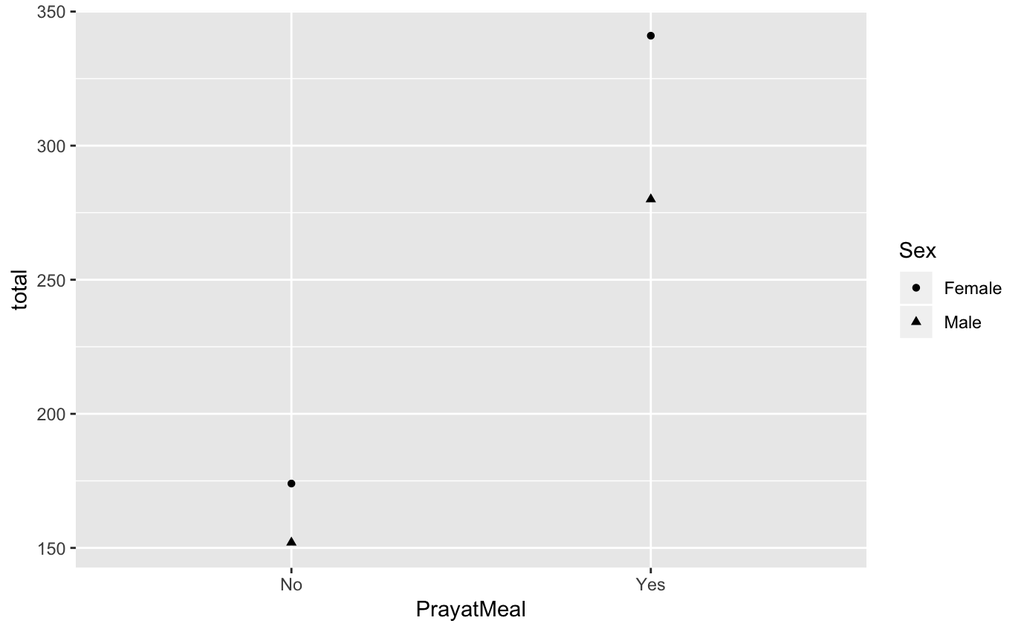

```r
PrayBeforeMeal %>%
  ggplot(aes( x = PrayatMeal, y= total)) +
  geom_point(aes(shape = Sex))
```

```r
PrayBeforeMeals <- matrix(c(174,152,341,280) ,nrow=2,byrow=TRUE)
# Created a matrix with the total values for each category
PrayBeforeMeals
```

```
     [,1] [,2]
[1,]  174  152
[2,]  341  280
```

```r
# Put names on the matrix so it would be easier to read
dimnames(PrayBeforeMeals) <- list(c("No","Yes"),c("Female","Male"))
names(dimnames(PrayBeforeMeals)) <- c("Pray","Gender")
PrayBeforeMeal
```

[output not shown]

```r
# Found the total amount of males and females that responded to this question
tot <- sum(PrayBeforeMeals)
tot
```

```
[1] 947
```

```r
# Found the proportion for each category
PrayBeforeMeals/tot
```

```
     Gender
Pray     Female      Male
  No  0.1837381 0.1605069
  Yes 0.3600845 0.2956705
```

```r
# Did a Chi Square test to see if gender and praying before a meal are correlated
prop.test(PrayBeforeMeals, correct = F)
```

```
    2-sample test for equality of proportions without continuity correction

data:  PrayBeforeMeals
X-squared = 0.20362, df = 1, p-value = 0.6518
alternative hypothesis: two.sided
95 percent confidence interval:
 -0.08218552  0.05144152
sample estimates:
   prop 1    prop 2
0.5337423 0.5491143
```

# Does Age and Living Area have an impact on Kids Table Cuttoff?

Lastly, I was interested in seeing how the age of the respondent, the area they lived in, and their families kid table age cut off differ. I know in my household it is always the grandchildren who are forced to the kids table ( no matter how old we are )! To do this I decided to create a jitter plot. A jitter plot adds a small amount of randcom variation to the location of each point, and is useful plot for handling overplotting. From the jitter plot, I was able to see that for all age ranges in a suburban living area is it most popular to have the kids table cut off be at 10 years old. People aged 60 from the suburban area have the highest total amount of people that have their kids cut off at 10 years old. It is interesting to see the variety between all different living areas. It is very interesting to see that the kids table cutoff age was mostly either 10 or 21, values in between occured but were not as popular for all three living areas.

It is important to note that the data was truncated to only include the first value for the age range so a jitter plot could be created!

```r
KidsTableCutoff <-
  TidyThanksgivingData %>%
  mutate( KidsTableAgeCutoff=gsub("or|younger|older","", KidsTableAgeCutoff)) %>%
  # Removed the words or, younger, and older from the KidsTableAgeCutoff
  mutate( Age=gsub("[-, 29, 44, +]","", Age))
```

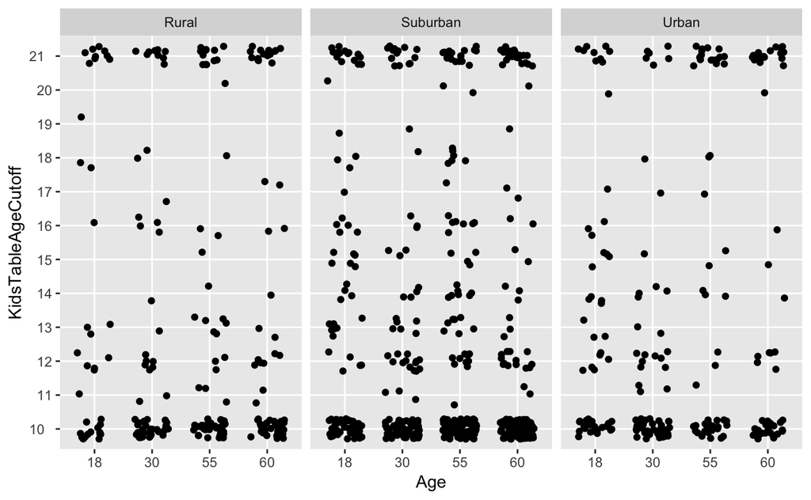

```r
KidsTableCutoff %>%
  filter(KidsTableAgeCutoff != "") %>%
  filter(Age != "") %>%
  filter(LivingArea != "") %>%
  ggplot(aes(x= Age, y = KidsTableAgeCutoff)) +
  geom_jitter(width = 0.3, height = 0.3) +
  facet_wrap( ~LivingArea)
```

# Conclusion

The purpose of this project was to explore Thanksgiving 2015 data and notice relationships between categorical variables. In each part of this project I made connections between different variables. It was hard at times to make different connections with just categorical variables so in some instances I truncated the data to only include the lower bound of a categorical variable making it a quantitative variable. Overall I enjoyed this project and learned a lot about Thanksgiving celebrations and the people that celebrate it!